# irAE Distribution

Mitchell Muniak

6/18/2019

This script describes the process by which i pulled irAE data from:

> Owen DH, Wei L, Bertino EM, Edd T, Villalona-Calero MA, He K, Shields PG, Carbone DP, Otterson GA. Incidence, Risk Factors, and Effect on Survival of Immune-related Adverse Events in Patients With Non-Small-cell Lung Cancer. Clin Lung Cancer. 2018;19(6):e893–e900. PMID: 30197259

in order to estimate the frequency of irAEs with different timings.

Here I input the Owen data as weeks

```r
irAE_weeks <- c(0, 4, 4, 4, 4, 4, 8, 8, 8, 8, 8, 12, 12, 16, 16, 24, 24, 28, 32, 32, 44, 56, 56, 72, 72, 144, 168)
```

I created a histogram to visualize the distribution.

I fiddled around with breaks and range to make a representative chart.

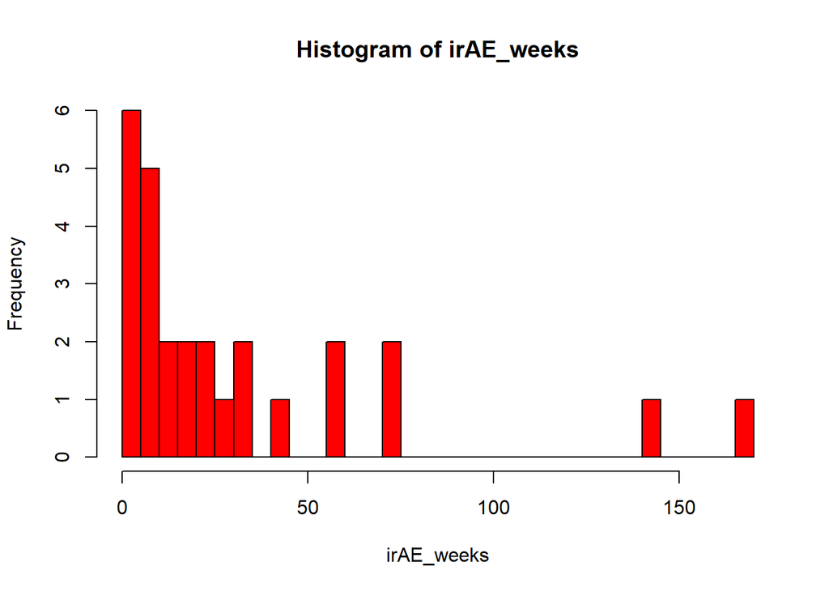

```r
hist(irAE_weeks, breaks = 50, col = "red", xlim = range(0,170))
```

I plugged in the percentile to view how many weeks will be needed to reach it. I cotinued to return to this function and change the quantile based on what we decided for sample size.

```r
quantile(irAE_weeks, .5350)
```

```
## 53.5%
##    16
```

The Owen data represented as a density graph. A line is included on the X axis to represent the total follow-up time that we eventually decided on.

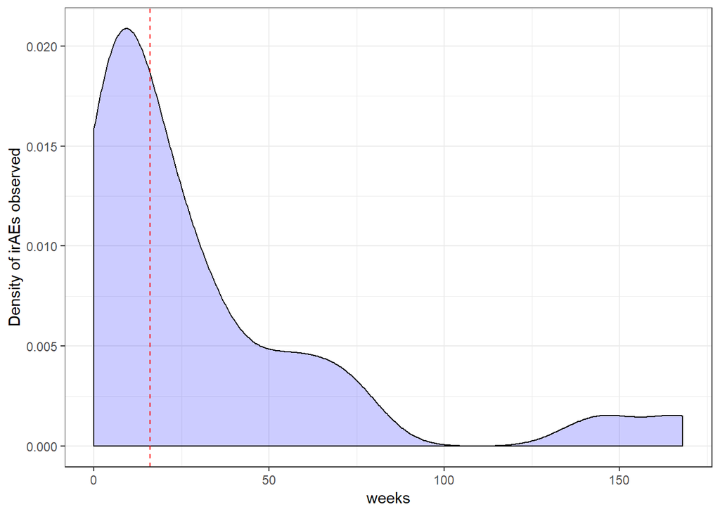

```r
df <- data.frame(weeks = irAE_weeks,
                 patient = seq(length(irAE_weeks)))
ggplot(df, aes(x = weeks)) +
  geom_density(fill = "blue", alpha = 0.2) +
  theme_bw() +
  geom_vline(aes(xintercept = quantile(weeks, 0.5350)), color= "red", linetype= "dashed") +
  labs(y = "Density of irAEs observed") +
ggsave("Fig2A_irAE-density.png", width = 4, height = 3)
```

```r
irAE_rate <- (27/91)
timing_and_samplesize <- function(compliance, samplesize, irAE_number){
  irAE_polulation_fraction <- irAE_number/(samplesize * compliance * irAE_rate)
time <- quantile(irAE_weeks, irAE_polulation_fraction)

out <- data.frame(compliance = compliance,
                  ss = samplesize,
                  irAE_number = irAE_number,
                  time = time)

return(out)
}
```

Inital sample size calculation/time with 0.7 compliance and 8 irAEs as constants.

```r
ss <- seq(50, 60)
newlist <- list()
for (N in ss){
  newlist[[N]] <- timing_and_samplesize(0.7, N, 8)
}
newlist <- dplyr::bind_rows(newlist)
timing_and_samplesize(0.7, 60, 8)
```

```
##           compliance ss irAE_number     time
## 64.19753%        0.7 60           8 26.76543
```

Sample size/time calculation with compliance split into 3 groups (0.7, 0.8, and 0.9)

Data is represented as a line graph.

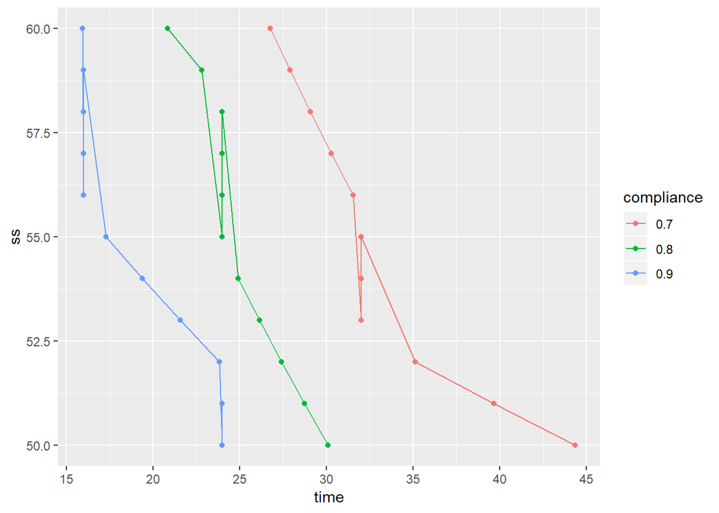

```r
comp.series <- seq(0.7, 0.9, by = 0.1)
comp.list <- list()
for (c in 1:length(comp.series)) {

  newlist <- list()

  for (N in ss){
    newlist[[N]] <- timing_and_samplesize(comp.series[c], N, 8)
  }

  comp.list[[c]] <- dplyr::bind_rows(newlist)
}

out <- dplyr::bind_rows(comp.list)

out %>%
  mutate(compliance = factor(compliance)) %>%
  ggplot(aes(x = time, y = ss)) +
  geom_point(aes(color = compliance)) +
  geom_line(aes(group= compliance, color = compliance))
```

The graph is reconsidered with sample size as the independent variable. We found the graph easier to read and draw conclusions from.

A line representing the average global min of the 3 compliance groups is added as a line.

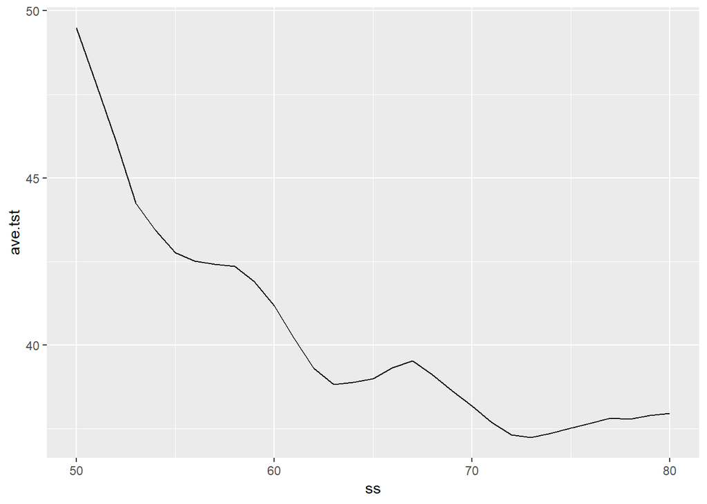

```r
ss2 <- seq(50, 80)
comp.series <- seq(0.7, 0.9, by = 0.1)
comp.list <- list()
for (c in 1:length(comp.series)) {

  newlist <- list()

  for (N in ss2){
    newlist[[N]] <- timing_and_samplesize(comp.series[c], N, 8)
  }

  comp.list[[c]] <- dplyr::bind_rows(newlist)
}

outall <-
  dplyr::bind_rows(comp.list) %>%
  mutate(total.study.time = ss/3 + time)

glomin <- outall %>%
  group_by(compliance) %>%
summarise(av_glo_min = min(total.study.time))

all_ave <- outall %>%
  select(-time) %>%
  spread(key = "compliance", value = "total.study.time") %>%
  mutate(ave.tst = (`0.7` + `0.8` + `0.9`)/3)
all_ave%>%
  ggplot(aes(x = ss, y = ave.tst)) +
  geom_line()
```

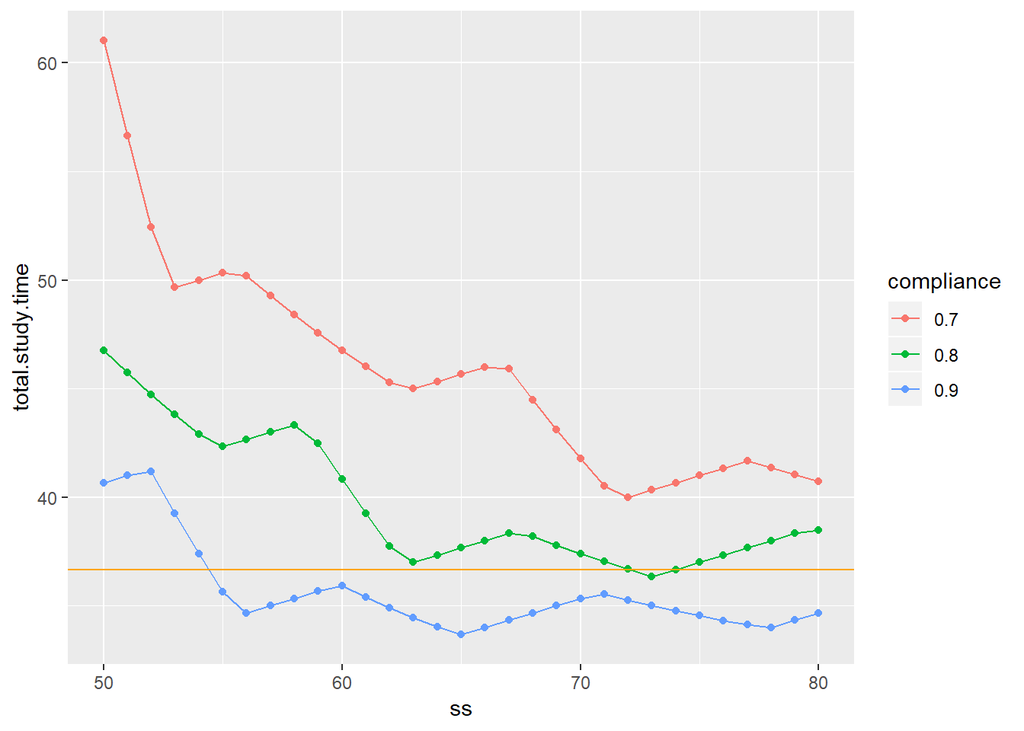

```r
outall %>%
  mutate(compliance = factor(compliance)) %>%
  ggplot(aes(x = ss, y = total.study.time)) +
  geom_point(aes(color = compliance)) +
  geom_line(aes(group= compliance, color = compliance))+
  geom_hline(yintercept = mean(glomin$av_glo_min), color = "orange")
```

The geom_point function is removed for aesthetic purposes. The average global min line is removed.

A line representing the average point of each line is added.

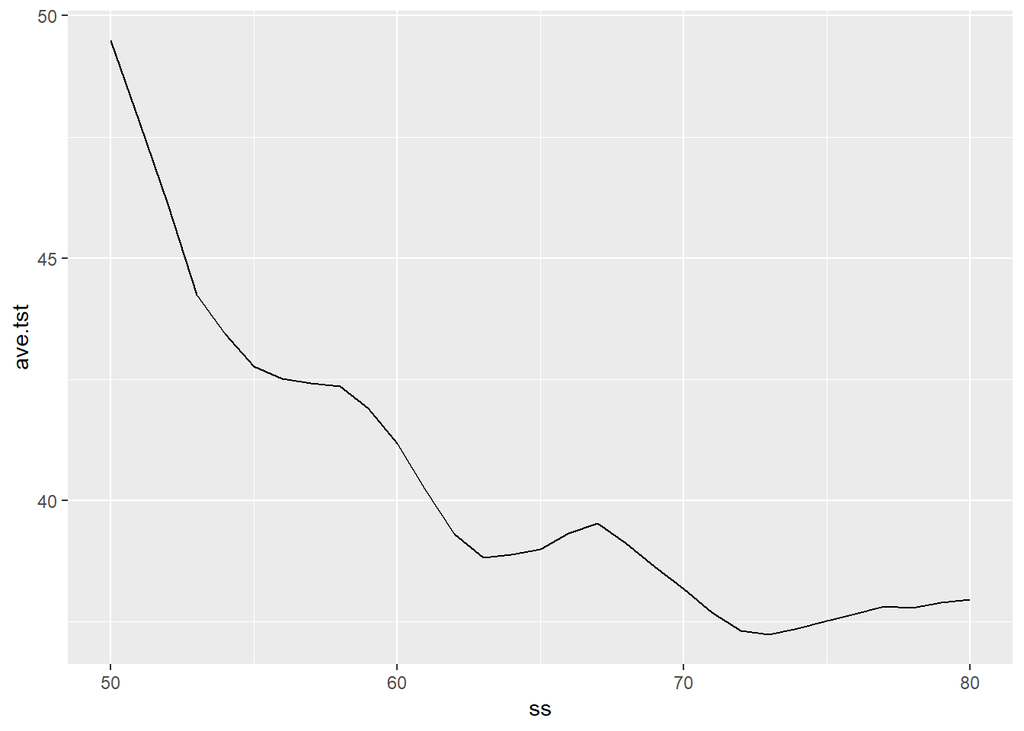

```r
ss2 <- seq(50, 80)
comp.series <- seq(0.7, 0.9, by = 0.1)
comp.list <- list()
for (c in 1:length(comp.series)) {

  newlist <- list()

  for (N in ss2){
    newlist[[N]] <- timing_and_samplesize(comp.series[c], N, 8)
  }

  comp.list[[c]] <- dplyr::bind_rows(newlist)
}

outall <-
  dplyr::bind_rows(comp.list) %>%
  mutate(total.study.time = ss/3 + time)

all_ave <- outall %>%
  select(-time) %>%
  spread(key = "compliance", value = "total.study.time") %>%
  mutate(ave.tst = (`0.7` + `0.8` + `0.9`)/3)
all_ave%>%
  ggplot(aes(x = ss, y = ave.tst)) +
  geom_line()
```

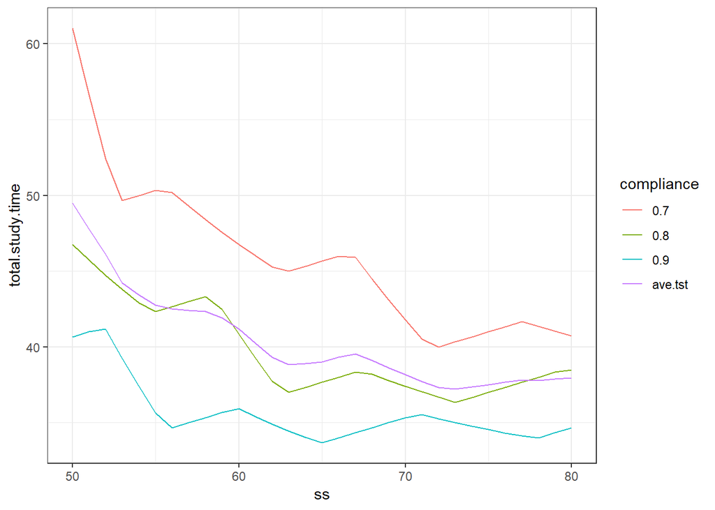

```r
allx2 <- all_ave %>%
  gather(`0.7`, `0.8`, `0.9`, ave.tst, key = "compliance", value = "total.study.time")

allx2 %>%
  mutate(compliance = factor(compliance)) %>%
  ggplot(aes(x = ss, y = total.study.time)) +
  geom_line(aes(group= compliance, color = compliance))+
  theme_bw()
```

The average point line is removed.

A floor line is added.

A vertical line is added to represent our targeted sample size.

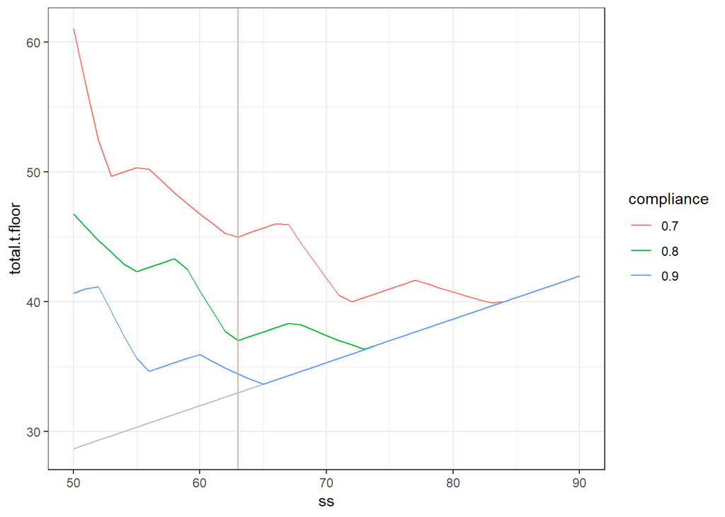

```r
ss2 <- seq(50, 90)
comp.series <- seq(0.7, 0.9, by = 0.1)
comp.list <- list()
for (c in 1:length(comp.series)) {

  newlist <- list()

  for (N in ss2){
    newlist[[N]] <- timing_and_samplesize(comp.series[c], N, 8)
  }

  comp.list[[c]] <- dplyr::bind_rows(newlist)
}

outall <-
  dplyr::bind_rows(comp.list) %>%
  mutate(total.study.time = ss/3 + time)

#all_ave <- outall %>%
#  select(-time) %>%
#  spread(key = "compliance", value = "total.study.time") %>%
#  mutate(ave.tst = (`0.7` + `0.8` + `0.9`)/3)
#all_ave%>%
#  ggplot(aes(x = ss, y = ave.tst)) +
#  geom_line()
#allx2 <- all_ave %>%
#  gather(`0.7`, `0.8`, `0.9`, ave.tst, key = "compliance", value = "total.study.time")

outall %>%
  mutate(compliance = factor(compliance)) %>%
  mutate(floor = ss/3+12) %>%
  mutate(total.t.floor = ifelse(total.study.time <= floor, floor, total.study.time)) %>%
  ggplot(aes(x = ss, y = total.t.floor)) +
  geom_line(aes(x = ss, y= floor), color= 'gray') +
  geom_line(aes(group = compliance, color = compliance)) +
  theme_bw() +
  geom_vline(aes(xintercept = 63), color = 'tan')
```

Appropriate labels are added to axises.

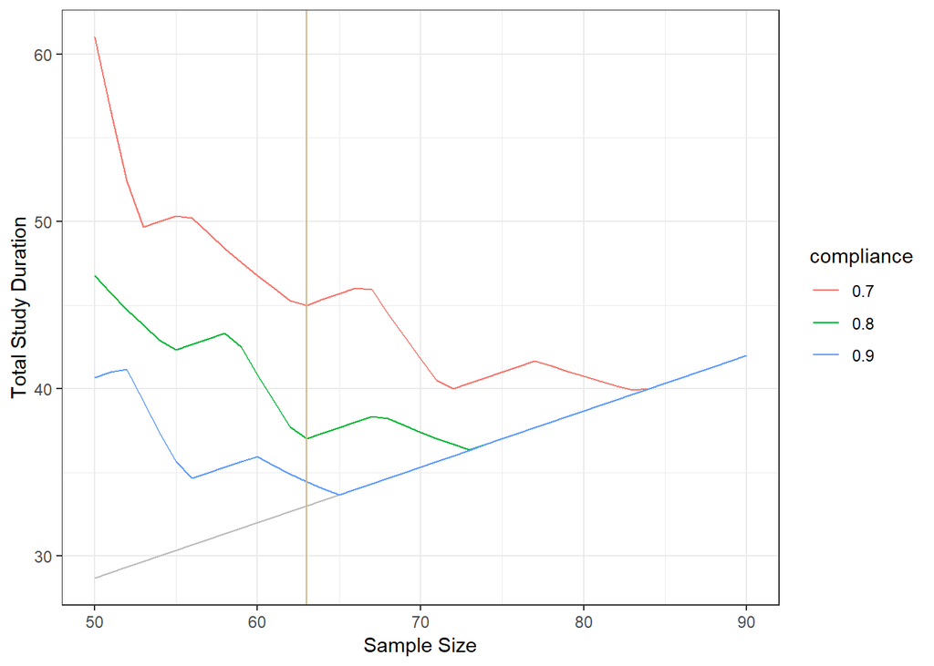

```r
ss2 <- seq(50, 90)
comp.series <- seq(0.7, 0.9, by = 0.1)
comp.list <- list()
for (c in 1:length(comp.series)) {

  newlist <- list()

  for (N in ss2){
    newlist[[N]] <- timing_and_samplesize(comp.series[c], N, 8)
  }

  comp.list[[c]] <- dplyr::bind_rows(newlist)
}

outall <-
  dplyr::bind_rows(comp.list) %>%
  mutate(total.study.time = ss/3 + time)

outall %>%
  mutate(compliance = factor(compliance)) %>%
  mutate(floor = ss/3+12) %>%
  mutate(total.t.floor = ifelse(total.study.time <= floor, floor, total.study.time)) %>%
  ggplot(aes(x = ss, y = total.t.floor)) +
  geom_line(aes(x= ss, y= floor), color= 'gray') +
  geom_line(aes(group= compliance, color = compliance)) +
  theme_bw()+
  geom_vline(aes(xintercept = 63), color= 'tan') +
  labs(x = "Sample Size", y = "Total Study Duration") +
  ggsave("Fig2B_sample-size_trial-duration.png", width = 4, height = 3)
```

```r
ss <- 63
accrual.rate <- 3

accr.time <- ss / accrual.rate

fu.time <- 37 - accr.time
```

Choosing a samples size of 63 patients and a total study duration of 37 weeks leads to 21 weeks of accruing patients and 16 weeks of follow up.

```r
frac.irAE <- sum(irAE_weeks <= fu.time) / 91 # Owen's cohort size
```

That means we should expect to observe irAEs in 0.1648352 of participants, or 10.3846154 participants. With an 80% compliance this results in 8.3076923 irAE samples.